# Beyond Your Sandbox

Press S to start

[figure not shown]

UW–Madison · College of Engineering

Beyond Your  
Sandbox

From individual contribution to collective intelligence

Ranjana Mehta

Interim Director, Grainger Institute for Engineering  
Grainger Institute for Engineering Professor, ISyE

[figure not shown]

Before we begin

A disclaimer

I'm not a *team science expert.*

1**Learned the hard way**

2**Read the evidence**

3**Trying my best to practice it**

Our 90 minutes

One question, carried through *every exercise*

You'll write your own question in a few minutes. Every exercise after that works on it.

Why leave the sandbox

Learn from past teams

Design what comes next

**Sandbox**Write your anchor question

**Warrant & cost**Is a team worth it?

**Reflect on past experiences**What happened last time

**Expert teams**Experts, or an expert team?

**Roles**Who does what, when

**FMEA**Science, or the team system?

**Team Charter**Agreements for your question

**Structural changes**What institutions must change

**Commit**One change, one ask

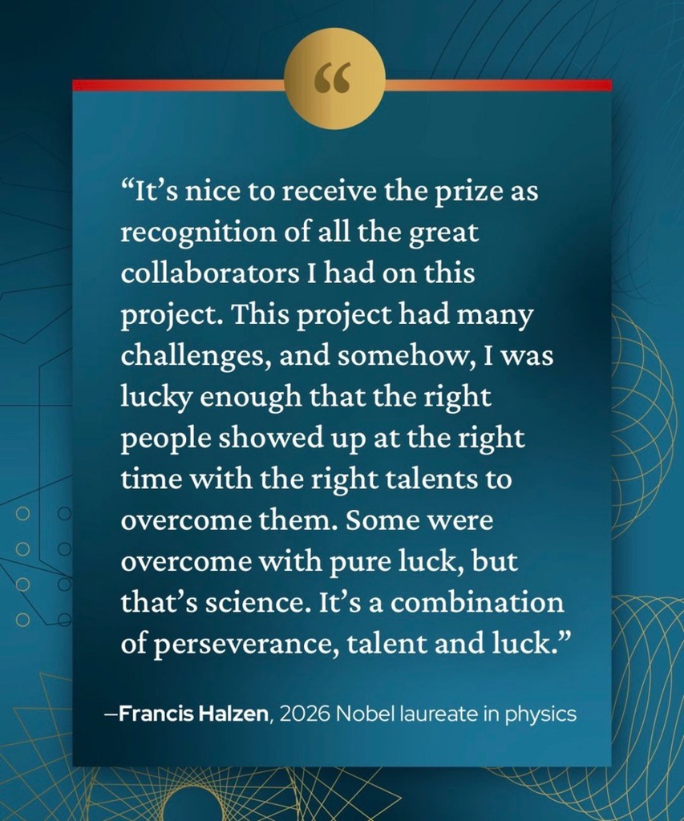

Why this matters

The right people, at *the right time*, with the right talents.

Francis Halzen, 2026 Nobel laureate in physics

Today: how do we make that *less a matter of luck?*

Opening · Why leave the sandbox

When a research question *outgrows the lab*

The scientific question, not the grant, is the reason to cross the boundary.

[figure not shown]

INTEGRATION

The problem crosses disciplines

No single perspective can frame it.

INTERDEPENDENCE

The parts affect one another

Separate work packages won't answer it.

CONTEXT

The answer must work in context

Users and partners shape the research.

AND MEANWHILE

The landscape is changing

Rising complexity · Fast technological change · More cross-sector teams · Funder interest in integrated research

Your turn · yellow Post-it

What question needs to be answered for your field to move forward?

And what has kept you from taking it on?

Move beyond your sandbox when **integration improves the question or makes the answer possible**, not because a bigger team or award is available.

Warrant & cost check

Is your question worth *the cost of a team?*

Warrant · score 0, 1 or 2

**Crosses disciplines**

*0**1**2*

**Parts affect one another**

*0**1**2*

**Must work in context**

*0**1**2*

Total warrant **___ / 6**

What this team will demand

If you land at Coordinate or Integrate, tick what you'll have to manage.

Diverse membershipDeep knowledge integrationLarge sizeGoals misaligned across teamsPermeable boundariesGeographic dispersionHigh task interdependence Coordination timeShared or diluted creditInvisible integration work

Where does it land?

0–2

**Stay in the sandbox**consult as needed

3–4

**Coordinate**shared plan, separate pieces

5–6

**Integrate**build an interdependent team

**The question decides whether to collaborate.** The costs decide what the team must plan for.

Exercise 1 · Learn from past teams

What happened in your *last large proposal?*

Led it or joined it: one Post-it per moment, under the stage where it happened.

Stage board on the wall

1**Development**Finding the opportunity and assembling the team

2**Conceptualization**Shaping the idea and the plan

3**Implementation**Writing, submitting and running the work

4**Translation**Launch, partners and uptake

Worked well Friction, delay or failure Wish we'd agreed earlier

Which problems were scientific, and which were coordination problems disguised as scientific ones?

Large proposals need **both scientific and collaborative excellence**. Design both on purpose.

Exercise 2 · Learn from past teams

A team of experts, or *an expert team?*

Two dots on the wall line: **blue** for where your team is now, **yellow** for where your question needs it to be.

Interdependence line on the wall

Those with the *biggest gaps* between their dots: what explains the gap?

Where did one person's work change another's?  
Who did the integration work, and was it credited?

Expertise creates potential. **Interdependence converts it into team capability.**

Exercise 3 · Learn from past teams

Who does what, *and when?*

Put your name on the role you play most. Then mark which stage needs each role.

Role grid on the wall

**Organizer**structures the work

**Doer**gets things done

**Challenger**questions assumptions

**Innovator**generates new ideas

**Team builder**builds trust

**Connector**links people and fields

Which roles are scarce in this room? Which role earns the least visible credit?

Collective intelligence depends on **complementary contributions that change with the work.**

Exercise 4 · In pairs

Did the science fail, or did *the team system fail first?*

Take one blue note from Exercise 1. Walk your partner through four questions.

1. **Intended**What were we trying to do?
2. **Happened**What happened? Earliest warning sign?
3. **Why**Which circle did it start in?
4. **Next time**What would we put in place earlier?

Failure from disciplined experimentation advances science. **Failure from an avoidable team-system defect doesn't.**

Exercise 5 · Design what comes next

Charter your *question*

Pick the 3 elements your question needs most.

#### Direction

**Purpose**What can this team do that members can't do separately?

**Success**What do scientific and collaborative success each look like?

**Roles**Who brings expertise, integration, coordination, challenge?

**Decision rights**Which decisions belong to the PI, subgroups, or the whole team?

#### Ways of working

**Integration**Where and how will ideas, methods, data and writing be combined?

**Cadence**Which meetings are needed, and what should never need one?

**Conflict**How will disagreement be raised and resolved?

**Credit**How will authorship, recognition and leadership be shared?

#### Course correction

**Learning**When will the team pause to review and adapt?

**Early warning**What signal triggers intervention or coaching?

With your Ex 4 partner: *why those three?*

Do any match your *blue* or *yellow* Post-its?

Which elements did *nobody pick?*

A charter turns **yesterday's blue notes into tomorrow's early warnings.**

Exercise 6 · Barrier-to-enabler wall

Faculty fix, or *institutional fix?*

Move every blue note to the level that could fix it. Then vote with 3 dots.

Barrier wall

**Individual**A behavior, skill or leadership practice

**Team**An agreement or recurring practice

**Institution**Infrastructure, policy, incentives, capacity

Vote · 3 dots each

Highest-impact barrier Most feasible fix Support I'd use myself

Finish the sentence

Teams would be more likely to succeed if my institution…

Sustainable team science needs **faculty practice and institutional infrastructure.**

Close

One change, one ask

One change

On my next collaborative proposal, I will introduce…

One ask

The one support that would most help me lead research at scale is…

**Post both notes on the Wall of Change.**

[figure not shown]

Thank you

References · the evidence behind each exercise

##### Sandbox & warrant check

Seven features that make team science hard (diversity, deep knowledge integration, size, goal misalignment, permeable boundaries, geographic dispersion, task interdependence): NRC (2015). Shifts since 2015 in technology and team makeup: NASEM (2025).

##### Ex 1 · Stages

Development, conceptualization, implementation, translation: Hall et al. (2012), as used in NASEM (2025) Conclusion 3-1.

##### Ex 2 · Expert team

Deep knowledge integration and high task interdependence: NRC (2015). Coordination, information sharing, conflict management; cohesion, shared mental models, transactive memory: NASEM (2025) ch. 3.

##### Ex 3 · Roles

Team Role Experience and Orientation (TREO): Mathieu et al. (2015).

##### Ex 4 · Failure debrief

Regular debriefs after each stage: NASEM (2025) Conclusion 3-1, implementation stage.

##### Ex 5 · Charter

Team charters and deliberate planning: NASEM (2025) Conclusion 3-1. Team launch: Penn State CTSI Team Science Toolkit. Bennett, Gadlin & Marchand (2018).

##### Ex 6 · Barrier wall

Incentives that discourage team science: NASEM (2025) Conclusion 4-1. Credit in promotion and tenure: Rec. 4-1. Institutional resources for teams: Rec. 4-4.

1. Bennett, L. M., Gadlin, H., & Marchand, C. (2018). *Collaboration and Team Science Field Guide* (2nd ed.). National Cancer Institute.
2. Hall, K. L., Vogel, A. L., Stipelman, B., Stokols, D., Morgan, G., & Gehlert, S. (2012). A four-phase model of transdisciplinary team-based research. *Translational Behavioral Medicine, 2*(4), 415–430.
3. Mathieu, J. E., Tannenbaum, S. I., Kukenberger, M. R., Donsbach, J. S., & Alliger, G. M. (2015). Team role experience and orientation. *Group & Organization Management, 40*(1), 6–34.
4. National Academies of Sciences, Engineering, and Medicine (2025). *The Science and Practice of Team Science.* National Academies Press.
5. National Research Council (2015). *Enhancing the Effectiveness of Team Science.* National Academies Press.
6. Penn State Clinical and Translational Science Institute. *Team Science Toolkit.* ctsi.psu.edu/services/toolkits/team-science/overview

### Now

### Your notes

### Steps

### Next